# Cars4U_Project

[figure not shown]

## Cars4U Project

## Context

Cars4U is a budding tech start-up that aims to find footholes in the Used car market as pre-owned car market has continued to grow over the past years (specifically between 2018-19). Unlike New Cars where pricing and supply are fairly deterministic and managed by OEMs (Original Equipment Manufacturer / except for dealership level discounts, used cars have huge uncertainty in both pricing and supply. Therefore, it is very important for Cars4U as a start-up to be able to determine what its future supply and pricing will be like in order to manage its future growth and keep a foothole in ever growing Used car market.

## Objective

Analyze the data and come up with a pricing model that can effectively predict the price of used cars and can help the business in devising profitable strategies using differential pricing.

## Key Questions

1. What car brands are the top selling in the Indian Market?
2. Is the market dominated by Economical or luxury cars?
3. What is the Median price for a new car?
4. What is the Median price for a pre-owned car?
5. What transmission type is preferred the most?
6. What Fuel_Type is preferred the most?
7. What is the market share for Pre-owned cars in general?

# **Sanity Check & Data PreProcessing**

## Loading and Exploring Data

```python
# this will help in making the Python code more structured automatically (good coding practice)
%load_ext nb_black
# To Suppress warning such as future warnings
import warnings

warnings.simplefilter(action="ignore", category=FutureWarning)
# For reading and manipulating data
import pandas as pd
import numpy as np

# Libraries used for data visualization
import seaborn as sns
import matplotlib.pyplot as plt

sns.set()

# Command to tell Python to actually display the graphs
%matplotlib inline
# Remove the limit from the number of displayed columns and rows so i can see the entire df when printing
pd.set_option("display.max_columns", None)
pd.set_option("display.max_rows", 200)

# Libraries used in Data Split (to test and train)
from sklearn.model_selection import train_test_split

# Libraries used for Linear Regression Model Building
from sklearn.linear_model import LinearRegression

# to check model performance
from sklearn.metrics import mean_absolute_error, mean_squared_error, r2_score
```

```python
# Importing data into data Variable which is our original Data
data = pd.read_csv(
    "https://raw.githubusercontent.com/miricoder/projects/main/Supervised_Learning_Regression/used_cars_data.csv"
)
# Creating Copy of The original Data
df = data.copy()
```

```python
# Making sure data is properly Loaded
df.head(5)
```

|  | S.No. | Name | Location | Year | Kilometers_Driven | Fuel_Type | Transmission | Owner_Type | Mileage | Engine | Power | Seats | New_Price | Price |
| --- | --- | --- | --- | --- | --- | --- | --- | --- | --- | --- | --- | --- | --- | --- |
| 0 | 0 | Maruti Wagon R LXI CNG | Mumbai | 2010 | 72000 | CNG | Manual | First | 26.6 km/kg | 998 CC | 58.16 bhp | 5.0 | 5.51 | 1.75 |
| 1 | 1 | Hyundai Creta 1.6 CRDi SX Option | Pune | 2015 | 41000 | Diesel | Manual | First | 19.67 kmpl | 1582 CC | 126.2 bhp | 5.0 | 16.06 | 12.50 |
| 2 | 2 | Honda Jazz V | Chennai | 2011 | 46000 | Petrol | Manual | First | 18.2 kmpl | 1199 CC | 88.7 bhp | 5.0 | 8.61 | 4.50 |
| 3 | 3 | Maruti Ertiga VDI | Chennai | 2012 | 87000 | Diesel | Manual | First | 20.77 kmpl | 1248 CC | 88.76 bhp | 7.0 | 11.27 | 6.00 |
| 4 | 4 | Audi A4 New 2.0 TDI Multitronic | Coimbatore | 2013 | 40670 | Diesel | Automatic | Second | 15.2 kmpl | 1968 CC | 140.8 bhp | 5.0 | 53.14 | 17.74 |

```python
# Checking the duplicate data
df.duplicated().sum()
```

```
0
```

- We don't have any duplicat Data in the Data Set

```python
df.info()
```

```
<class 'pandas.core.frame.DataFrame'>
RangeIndex: 7253 entries, 0 to 7252
Data columns (total 14 columns):
 #   Column             Non-Null Count  Dtype
---  ------             --------------  -----
 0   S.No.              7253 non-null   int64
 1   Name               7253 non-null   object
 2   Location           7253 non-null   object
 3   Year               7253 non-null   int64
 4   Kilometers_Driven  7253 non-null   int64
 5   Fuel_Type          7253 non-null   object
 6   Transmission       7253 non-null   object
 7   Owner_Type         7253 non-null   object
 8   Mileage            7251 non-null   object
 9   Engine             7207 non-null   object
 10  Power              7078 non-null   object
 11  Seats              7200 non-null   float64
 12  New_Price          7253 non-null   float64
 13  Price              6019 non-null   float64
dtypes: float64(3), int64(3), object(8)
memory usage: 793.4+ KB
```

- We have 14 columns with, 6 Numerical and 8 Categorical

```python
# Display column and row values using pyton 3's f-string
print(f"There are {df.shape[0]} rows and {df.shape[1]} columns.")

# Looking at the 10 random sample rows done using np.random
# Because looking at random values will give you better understaning than head or tail values
np.random.seed(1)
df.sample(10)
```

```
There are 7253 rows and 14 columns.
```

|  | S.No. | Name | Location | Year | Kilometers_Driven | Fuel_Type | Transmission | Owner_Type | Mileage | Engine | Power | Seats | New_Price | Price |
| --- | --- | --- | --- | --- | --- | --- | --- | --- | --- | --- | --- | --- | --- | --- |
| 2397 | 2397 | Ford EcoSport 1.5 Petrol Trend | Kolkata | 2016 | 21460 | Petrol | Manual | First | 17.0 kmpl | 1497 CC | 121.36 bhp | 5.0 | 9.47 | 6.00 |
| 3777 | 3777 | Maruti Wagon R VXI 1.2 | Kochi | 2015 | 49818 | Petrol | Manual | First | 21.5 kmpl | 1197 CC | 81.80 bhp | 5.0 | 5.44 | 4.11 |
| 4425 | 4425 | Ford Endeavour 4x2 XLT | Hyderabad | 2007 | 130000 | Diesel | Manual | First | 13.1 kmpl | 2499 CC | 141 bhp | 7.0 | 35.29 | 6.00 |
| 3661 | 3661 | Mercedes-Benz E-Class E250 CDI Avantgrade | Coimbatore | 2016 | 39753 | Diesel | Automatic | First | 13.0 kmpl | 2143 CC | 201.1 bhp | 5.0 | 86.97 | 35.28 |
| 4514 | 4514 | Hyundai Xcent 1.2 Kappa AT SX Option | Kochi | 2016 | 45560 | Petrol | Automatic | First | 16.9 kmpl | 1197 CC | 82 bhp | 5.0 | 8.23 | 6.34 |
| 599 | 599 | Toyota Innova Crysta 2.8 ZX AT | Coimbatore | 2019 | 40674 | Diesel | Automatic | First | 11.36 kmpl | 2755 CC | 171.5 bhp | 7.0 | 28.05 | 24.82 |
| 186 | 186 | Mercedes-Benz E-Class E250 CDI Avantgrade | Bangalore | 2014 | 37382 | Diesel | Automatic | First | 13.0 kmpl | 2143 CC | 201.1 bhp | 5.0 | 86.97 | 32.00 |
| 305 | 305 | Audi A6 2011-2015 2.0 TDI Premium Plus | Kochi | 2014 | 61726 | Diesel | Automatic | First | 17.68 kmpl | 1968 CC | 174.33 bhp | 5.0 | 67.10 | 20.77 |
| 4582 | 4582 | Hyundai i20 1.2 Magna | Kolkata | 2011 | 36000 | Petrol | Manual | First | 18.5 kmpl | 1197 CC | 80 bhp | 5.0 | 10.25 | 2.50 |
| 5434 | 5434 | Honda WR-V Edge Edition i-VTEC S | Kochi | 2019 | 13913 | Petrol | Manual | First | 17.5 kmpl | 1199 CC | 88.7 bhp | 5.0 | 9.36 | 8.20 |

- `S.No.` column can be dropped since Pandas already provides us with row Ids
- `Mileage,Engine,Power` columns needs to be turned into numerics
- Year columns seems ok so far
- `Fuel_Type,Transmission,Owner_Type` will be applied One-Hot Encoding using Dummy variables before Modeling begins
- `Name` contains lengthy names and too many charecters in each name, it will need to be Text Processed otherwise it will be an issue in EDA and Modeling process

**Basic EDA-Statistical Summary before going any further to see how our data is looking**

```python
df.describe().T
```

|  | count | mean | std | min | 25% | 50% | 75% | max |
| --- | --- | --- | --- | --- | --- | --- | --- | --- |
| S.No. | 7253.0 | 3626.000000 | 2093.905084 | 0.00 | 1813.00 | 3626.00 | 5439.00 | 7252.0 |
| Year | 7253.0 | 2013.365366 | 3.254421 | 1996.00 | 2011.00 | 2014.00 | 2016.00 | 2019.0 |
| Kilometers_Driven | 7253.0 | 58699.063146 | 84427.720583 | 171.00 | 34000.00 | 53416.00 | 73000.00 | 6500000.0 |
| Seats | 7200.0 | 5.279722 | 0.811660 | 0.00 | 5.00 | 5.00 | 5.00 | 10.0 |
| New_Price | 7253.0 | 21.307322 | 24.256314 | 3.91 | 7.88 | 11.30 | 21.69 | 375.0 |
| Price | 6019.0 | 9.479468 | 11.187917 | 0.44 | 3.50 | 5.64 | 9.95 | 160.0 |

- Count of Price is less than other columns, this could be due to missing values

**Dropping the S.No Column**

```python
df.drop(["S.No."], axis=1, inplace=True)
# Validating that S.No. column is removed by checking  df.columns
df.columns
```

```
Index(['Name', 'Location', 'Year', 'Kilometers_Driven', 'Fuel_Type',
       'Transmission', 'Owner_Type', 'Mileage', 'Engine', 'Power', 'Seats',
       'New_Price', 'Price'],
      dtype='object')
```

**Text Processing - Fixing Name column prior to EDA and Modelling**

Carrying out quick analysis first to get understanding of word count and its distribution before coming up with best fit solution

```python
# How many letter and words are in the car brand names?
auto_data = pd.DataFrame(
    data=[
        (i, len(i), len(i.split())) if i == i else (i, 0, 0)
        for i in df["Name"].str.strip().str.title().unique()
    ],
    columns=["Name", "Number of Letters", "Number of Words"],
)
auto_data.head(10)
```

|  | Name | Number of Letters | Number of Words |
| --- | --- | --- | --- |
| 0 | Maruti Wagon R Lxi Cng | 22 | 5 |
| 1 | Hyundai Creta 1.6 Crdi Sx Option | 32 | 6 |
| 2 | Honda Jazz V | 12 | 3 |
| 3 | Maruti Ertiga Vdi | 17 | 3 |
| 4 | Audi A4 New 2.0 Tdi Multitronic | 31 | 6 |
| 5 | Hyundai Eon Lpg Era Plus Option | 31 | 6 |
| 6 | Nissan Micra Diesel Xv | 22 | 4 |
| 7 | Toyota Innova Crysta 2.8 Gx At 8S | 33 | 7 |
| 8 | Volkswagen Vento Diesel Comfortline | 35 | 4 |
| 9 | Tata Indica Vista Quadrajet Ls | 30 | 5 |

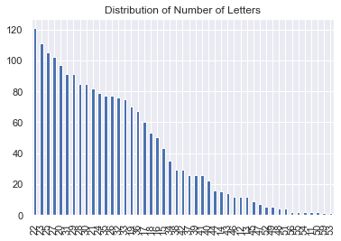

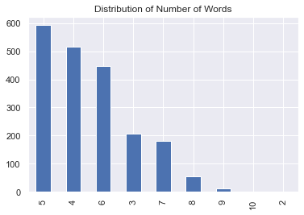

```
These are the Car Names with the most words in the name:
```

```
460    Bmw X5 2014-2019 Xdrive 30D Design Pure Experi...
Name: Name, dtype: object
```

```python
auto_data["Number of Letters"].value_counts().plot.bar()
plt.title("Distribution of Number of Letters")
plt.show()

auto_data["Number of Words"].value_counts().plot.bar()
plt.title("Distribution of Number of Words")
plt.show()

print("These are the Car Names with the most words in the name:")
auto_data.loc[
    auto_data["Number of Words"] == auto_data["Number of Words"].max(), "Name"
]
```

Making a copy of origin df to df2 before shortening and altering `Name` column

```python
df2 = df.copy()
```

```python
# Take only the brand name before space for each vehicle
df2["Name"] = [x.split(maxsplit=1)[0] for x in df["Name"]]
# df["Name_Shortened"]
np.random.seed(1)
df2["Name"].sample(10)
```

```
2397             Ford
3777           Maruti
4425             Ford
3661    Mercedes-Benz
4514          Hyundai
599            Toyota
186     Mercedes-Benz
305              Audi
4582          Hyundai
5434            Honda
Name: Name, dtype: object
```

**Quick Sanity Check after Text Processing**

```python
df2.info()
```

```
<class 'pandas.core.frame.DataFrame'>
RangeIndex: 7253 entries, 0 to 7252
Data columns (total 13 columns):
 #   Column             Non-Null Count  Dtype
---  ------             --------------  -----
 0   Name               7253 non-null   object
 1   Location           7253 non-null   object
 2   Year               7253 non-null   int64
 3   Kilometers_Driven  7253 non-null   int64
 4   Fuel_Type          7253 non-null   object
 5   Transmission       7253 non-null   object
 6   Owner_Type         7253 non-null   object
 7   Mileage            7251 non-null   object
 8   Engine             7207 non-null   object
 9   Power              7078 non-null   object
 10  Seats              7200 non-null   float64
 11  New_Price          7253 non-null   float64
 12  Price              6019 non-null   float64
dtypes: float64(3), int64(2), object(8)
memory usage: 736.8+ KB
```

- Name column is the first and S.No. column is now gone, our data is down total of 13 columns, with 8 Categorical and 5 numerical
- Mileage(`7251`), Engine(`7207`), Power(`7078`), Seats(`7200`), Price(`6019`) all have missing values in them

### Processing Data - Before Performing Statisical Analysis

**Converting `Mileage` column to numeric**

```python
# Looping through to see how many columns have "km/kg" or "kmpl" endings
mileage_endings = ("km/kg", " km/kg", "kmpl")
mileage_cols = []
for colname in df2.columns[
    df2.dtypes == "object"
]:  # only need to consider string columns
    if (
        df2[colname].str.endswith(mileage_endings).any()
    ):  # using `.str` so I can use an element-wise string method
        mileage_cols.append(colname)
print(mileage_cols)
```

```
['Mileage']
```

```python
def mileage_to_num(mileage_val):
    """
    This function takes in a string representing in Mileage in km/kg & kmpl
    and converts it to a number. For Example, 26.6 km/kg to 26.6
    or 19.67 kmpl to 19.67
    """
    if isinstance(mileage_val, str):  # checks if `mileage_val` is a string
        return float(mileage_val.replace("km/kg", "").replace("kmpl", ""))
    else:
        return np.nan


for colname in mileage_cols:
    df2[colname] = df2[colname].apply(mileage_to_num)
# Quick Sanity Check
df2[mileage_cols].head()
```

|  | Mileage |
| --- | --- |
| 0 | 26.60 |
| 1 | 19.67 |
| 2 | 18.20 |
| 3 | 20.77 |
| 4 | 15.20 |

**Converting `Engine` column to numeric**

```python
# Looping through to see how many columns have "bhp" endings
engine_endings = "CC"
engine_cols = []
for colname in df2.columns[
    df2.dtypes == "object"
]:  # only need to consider string columns
    if (
        df2[colname].str.endswith(engine_endings).any()
    ):  # using `.str` so I can use an element-wise string method
        engine_cols.append(colname)
print(engine_cols)
```

```
['Engine']
```

```python
def engine_to_num(engine_val):
    """
    This function takes in a string representing in Mileage in CC
    and converts it to a number.
    """
    if isinstance(engine_val, str):  # checks if `mileage_val` is a string
        return float(engine_val.replace("CC", ""))
    else:
        return np.nan


for colname in engine_cols:
    df2[colname] = df2[colname].apply(engine_to_num)
# Quick Sanity Check
df2[engine_cols].head()
```

|  | Engine |
| --- | --- |
| 0 | 998.0 |
| 1 | 1582.0 |
| 2 | 1199.0 |
| 3 | 1248.0 |
| 4 | 1968.0 |

**Converting `Power` column to numeric**

```python
# Looping through to see how many columns have "CC" endings
power_endings = "bhp"
power_cols = []
for colname in df2.columns[
    df2.dtypes == "object"
]:  # only need to consider string columns
    if (
        df2[colname].str.endswith(power_endings).any()
    ):  # using `.str` so I can use an element-wise string method
        power_cols.append(colname)
print(power_cols)
```

```
['Power']
```

```python
def power_to_num(power_val):
    """
    This function takes in a string representing in Mileage in bhp
    and converts it to a number.
    """
    if isinstance(power_val, str):  # checks if `mileage_val` is a string
        return float(power_val.replace("bhp", ""))
    else:
        return np.nan


for colname in power_cols:
    df2[colname] = df2[colname].apply(power_to_num)
# Quick Sanity Check
df2[power_cols].head()
```

|  | Power |
| --- | --- |
| 0 | 58.16 |
| 1 | 126.20 |
| 2 | 88.70 |
| 3 | 88.76 |
| 4 | 140.80 |

```python
df2.info()
```

```
<class 'pandas.core.frame.DataFrame'>
RangeIndex: 7253 entries, 0 to 7252
Data columns (total 13 columns):
 #   Column             Non-Null Count  Dtype
---  ------             --------------  -----
 0   Name               7253 non-null   object
 1   Location           7253 non-null   object
 2   Year               7253 non-null   int64
 3   Kilometers_Driven  7253 non-null   int64
 4   Fuel_Type          7253 non-null   object
 5   Transmission       7253 non-null   object
 6   Owner_Type         7253 non-null   object
 7   Mileage            7251 non-null   float64
 8   Engine             7207 non-null   float64
 9   Power              7078 non-null   float64
 10  Seats              7200 non-null   float64
 11  New_Price          7253 non-null   float64
 12  Price              6019 non-null   float64
dtypes: float64(6), int64(2), object(5)
memory usage: 736.8+ KB
```

- Data set is down to 13 columns from 14 and Mileage, Power, Enginer columns are now numeric

**Missing Value Treatment**

##### Quick Sanity Check

```python
# Which columns has the most missing values**
df2.isnull().sum().sort_values(ascending=False)
```

```
Price                1234
Power                 175
Seats                  53
Engine                 46
Mileage                 2
Name                    0
Location                0
Year                    0
Kilometers_Driven       0
Fuel_Type               0
Transmission            0
Owner_Type              0
New_Price               0
dtype: int64
```

- `Price` column has the most values in it and since Price and its a problem since this is the column we are trying to predict
- `Power, Seats, Engine` also has missing values needs to be looked at
- `Mileage` has the least missing values, still needs to be looked at and treated

```python
# What is the null percentage per rows in column that have null values
column_name = ["Price", "Power", "Seats", "Engine", "Mileage"]
for i in df2[column_name]:
    print(
        f" Perecentage of null values in [{i}] is -->  {(sum(df2[i].isna()) / df2.shape[0]) * 100} '%'"
    )
```

```
 Perecentage of null values in [Price] is -->  17.01364952433476 '%'
 Perecentage of null values in [Power] is -->  2.4127947056390457 '%'
 Perecentage of null values in [Seats] is -->  0.7307321108506825 '%'
 Perecentage of null values in [Engine] is -->  0.6342203226251206 '%'
 Perecentage of null values in [Mileage] is -->  0.02757479663587481 '%'
```

**Price is our Target variable and has concerning amount of null values at 17% - We will drop all null values**

- Other Variables will be imputed with their mean values later

```python
df2.dropna(subset=["Price"], inplace=True)
```

```python
# let us reset the dataframe index
df2.reset_index(inplace=True, drop=True)
```

*Understading the pattern of null values for below Variables before imputing the values*

- Power 175 (null values-2.412%)
- Seats 53 (null values-0.730%)
- Engine 46 (null values-0.63%)
- Mileage 2 (null values-0.027%)

```python
# counting the number of missing values per row
df2.isnull().sum(axis=1).value_counts()
```

```
0    5872
1     107
3      36
2       4
dtype: int64
```

- 5872 have `0` missing values, 107 has `1` missing values, 36 has `3` missing values, 4 has `2` missing values in them

```python
# Checking the rows with 1 missing values
num_missing = df2.isnull().sum(axis=1)
df2[num_missing == 1].sample(n=5)
```

|  | Name | Location | Year | Kilometers_Driven | Fuel_Type | Transmission | Owner_Type | Mileage | Engine | Power | Seats | New_Price | Price |
| --- | --- | --- | --- | --- | --- | --- | --- | --- | --- | --- | --- | --- | --- |
| 5426 | Hyundai | Chennai | 2006 | 85000 | Petrol | Manual | Third | 0.00 | 1086.0 | NaN | 5.0 | 4.550 | 1.30 |
| 1068 | Toyota | Pune | 2012 | 225000 | Diesel | Manual | Second | 23.59 | 1364.0 | NaN | 5.0 | 8.525 | 2.60 |
| 4954 | Toyota | Coimbatore | 2013 | 62601 | Diesel | Manual | First | 23.59 | 1364.0 | NaN | 5.0 | 8.525 | 4.67 |
| 4351 | Maruti | Jaipur | 2003 | 55000 | Petrol | Manual | Third | 15.90 | 1298.0 | NaN | 5.0 | 7.880 | 0.70 |
| 5873 | Hyundai | Pune | 2006 | 47200 | Petrol | Manual | Second | 17.00 | 1086.0 | NaN | 5.0 | 4.550 | 1.20 |

```python
# Checking the rows with 3 missing values
num_missing = df2.isnull().sum(axis=1)
df2[num_missing == 3].sample(n=5)
```

|  | Name | Location | Year | Kilometers_Driven | Fuel_Type | Transmission | Owner_Type | Mileage | Engine | Power | Seats | New_Price | Price |
| --- | --- | --- | --- | --- | --- | --- | --- | --- | --- | --- | --- | --- | --- |
| 1385 | Honda | Pune | 2004 | 115000 | Petrol | Manual | Second | 0.0 | NaN | NaN | NaN | 13.580 | 1.50 |
| 2264 | Toyota | Pune | 2012 | 24500 | Petrol | Manual | Second | 18.3 | NaN | NaN | NaN | 8.525 | 2.95 |
| 3404 | Maruti | Jaipur | 2006 | 125000 | Petrol | Manual | Fourth & Above | 16.1 | NaN | NaN | NaN | 7.880 | 2.35 |
| 4152 | Land | Mumbai | 2003 | 75000 | Diesel | Automatic | Second | 0.0 | NaN | NaN | NaN | 120.000 | 16.11 |
| 208 | Maruti | Kolkata | 2010 | 42001 | Petrol | Manual | First | 16.1 | NaN | NaN | NaN | 7.880 | 2.11 |

- Where `Engine` is missing, so does the `Power` & `Seats` rows

```python
# Checking the rows with 2 missing values
num_missing = df2.isnull().sum(axis=1)
df2[num_missing == 2].sample(n=2)
```

|  | Name | Location | Year | Kilometers_Driven | Fuel_Type | Transmission | Owner_Type | Mileage | Engine | Power | Seats | New_Price | Price |
| --- | --- | --- | --- | --- | --- | --- | --- | --- | --- | --- | --- | --- | --- |
| 3800 | Ford | Mumbai | 2012 | 129000 | Diesel | Automatic | First | 12.8 | 2953.0 | NaN | NaN | 35.29 | 7.00 |
| 5893 | Maruti | Chennai | 2008 | 51000 | Petrol | Manual | Second | 19.5 | 1061.0 | NaN | NaN | 7.88 | 1.75 |

There is a pattern which is analyzed programatically as below, and also all missing rows are numerical

```python
for n in num_missing.value_counts().sort_index().index:
    if n > 0:
        print(f"For the rows with exactly {n} missing values, NAs are found in:")
        n_miss_per_col = df2[num_missing == n].isnull().sum()
        print(n_miss_per_col[n_miss_per_col > 0])
        print("\n\n")
```

```
For the rows with exactly 1 missing values, NAs are found in:
Mileage      2
Power      103
Seats        2
dtype: int64



For the rows with exactly 2 missing values, NAs are found in:
Power    4
Seats    4
dtype: int64



For the rows with exactly 3 missing values, NAs are found in:
Engine    36
Power     36
Seats     36
dtype: int64
```

- As we can columns are either missing together or missing in seperate quantities and orders. Price is definetly affected
- We will not drop these columns as we need them for our model, specially price. We will impute them with thei mean values

*Imputing the numerical columns values with their mean values, keeping in mind that we will also need to do an Outlier treatment as means are prone to be affected by outliers*

```python
# Using `fillna` with a numeric volumn
# We need to make sure of the column sequence to stay as per data column sequence, otherwise some rows
# won't be impupted into their mean value
numeric_cols = ["Mileage", "Engine", "Power", "Seats"]
for i in numeric_cols:
    print(df2[i].isnull().sum())
    df2[i].fillna(df2[i].mean(), inplace=True)  # mean imputation
    df2[i].isnull().sum()
```

```
2
36
143
42
```

```python
# Which columns has the most missing values**
df2.isnull().sum().sort_values(ascending=False)
```

```
Name                 0
Location             0
Year                 0
Kilometers_Driven    0
Fuel_Type            0
Transmission         0
Owner_Type           0
Mileage              0
Engine               0
Power                0
Seats                0
New_Price            0
Price                0
dtype: int64
```

- Now `Engine`, `Power`, `Seats`,`Price` are containing 0 missing values

## Base Model - to help understand performance progress in our final model

Data must not include missing values, long texts must be processed, textual content must be converted to numeric before it can be one-hot encoded and further built for a Base Model which is very useful in the end for comparison reasons

Reusable Method for Performance checking of the model

```python
# function to compute adjusted R-squared
def adj_r2_score(predictors, targets, predictions):
    r2 = r2_score(targets, predictions)
    n = predictors.shape[0]
    k = predictors.shape[1]
    return 1 - ((1 - r2) * (n - 1) / (n - k - 1))


# function to compute MAPE
def mape_score(targets, predictions):
    return np.mean(np.abs(targets - predictions) / targets) * 100


# function to compute different metrics to check performance of a regression model
def model_performance_regression(model, predictors, target):
    """
    Function to compute different metrics to check regression model performance

    model: regressor
    predictors: independent variables
    target: dependent variable
    """

    # predicting using the independent variables
    pred = model.predict(predictors)

    r2 = r2_score(target, pred)  # to compute R-squared
    adjr2 = adj_r2_score(predictors, target, pred)  # to compute adjusted R-squared
    rmse = np.sqrt(mean_squared_error(target, pred))  # to compute RMSE
    mae = mean_absolute_error(target, pred)  # to compute MAE
    mape = mape_score(target, pred)  # to compute MAPE

    # creating a dataframe of metrics
    df_perf = pd.DataFrame(
        {
            "RMSE": rmse,
            "MAE": mae,
            "R-squared": r2,
            "Adj. R-squared": adjr2,
            "MAPE": mape,
        },
        index=[0],
    )

    return df_perf
```

```python
# Making a copy of the data to build base model on
base = df2.copy()
```

```python
# Define dependent Variable
base_X = base.drop(["Price"], axis=1)
base_y = base["Price"]
```

```python
# One Hot Encoding - Creating dummy variables
base_X = pd.get_dummies(
    base_X,
    columns=base_X.select_dtypes(include=["object", "category"]).columns.tolist(),
    drop_first=True,
)
base_X.head()
```

|  | Year | Kilometers_Driven | Mileage | Engine | Power | Seats | New_Price | Name_Audi | Name_BMW | Name_Bentley | Name_Chevrolet | Name_Datsun | Name_Fiat | Name_Force | Name_Ford | Name_Honda | Name_Hyundai | Name_ISUZU | Name_Isuzu | Name_Jaguar | Name_Jeep | Name_Lamborghini | Name_Land | Name_Mahindra | Name_Maruti | Name_Mercedes-Benz | Name_Mini | Name_Mitsubishi | Name_Nissan | … |
| --- | --- | --- | --- | --- | --- | --- | --- | --- | --- | --- | --- | --- | --- | --- | --- | --- | --- | --- | --- | --- | --- | --- | --- | --- | --- | --- | --- | --- | --- | --- |
| 0 | 2010 | 72000 | 26.60 | 998.0 | 58.16 | 5.0 | 5.51 | 0 | 0 | 0 | 0 | 0 | 0 | 0 | 0 | 0 | 0 | 0 | 0 | 0 | 0 | 0 | 0 | 0 | 1 | 0 | 0 | 0 | 0 | … |
| 1 | 2015 | 41000 | 19.67 | 1582.0 | 126.20 | 5.0 | 16.06 | 0 | 0 | 0 | 0 | 0 | 0 | 0 | 0 | 0 | 1 | 0 | 0 | 0 | 0 | 0 | 0 | 0 | 0 | 0 | 0 | 0 | 0 | … |
| 2 | 2011 | 46000 | 18.20 | 1199.0 | 88.70 | 5.0 | 8.61 | 0 | 0 | 0 | 0 | 0 | 0 | 0 | 0 | 1 | 0 | 0 | 0 | 0 | 0 | 0 | 0 | 0 | 0 | 0 | 0 | 0 | 0 | … |
| 3 | 2012 | 87000 | 20.77 | 1248.0 | 88.76 | 7.0 | 11.27 | 0 | 0 | 0 | 0 | 0 | 0 | 0 | 0 | 0 | 0 | 0 | 0 | 0 | 0 | 0 | 0 | 0 | 1 | 0 | 0 | 0 | 0 | … |
| 4 | 2013 | 40670 | 15.20 | 1968.0 | 140.80 | 5.0 | 53.14 | 1 | 0 | 0 | 0 | 0 | 0 | 0 | 0 | 0 | 0 | 0 | 0 | 0 | 0 | 0 | 0 | 0 | 0 | 0 | 0 | 0 | 0 | … |

```python
# Split the data into train and test data
x_trainBase, x_testBase, y_trainBase, y_testBase = train_test_split(
    base_X, base_y, test_size=0.3, random_state=1
)
print("Number of rows in base trains data =", x_trainBase.shape[0])
print("Number of rows in base test data =", x_testBase.shape[0])
```

```
Number of rows in base trains data = 4213
Number of rows in base test data = 1806
```

```python
# Fitting a linear model
base_lin_reg_model = LinearRegression()
base_lin_reg_model.fit(x_trainBase, y_trainBase)
```

```
LinearRegression()
```

```python
# Check model Performance
print("Base - Training Performance\n")
base_lin_reg_model_train_perf = model_performance_regression(
    base_lin_reg_model, x_trainBase, y_trainBase
)
base_lin_reg_model_train_perf
```

```
Base - Training Performance
```

|  | RMSE | MAE | R-squared | Adj. R-squared | MAPE |
| --- | --- | --- | --- | --- | --- |
| 0 | 5.319461 | 2.861587 | 0.778703 | 0.775775 | 57.306303 |

```python
# Check model Performance
print("Base - Test Performance\n")
base_lin_reg_model_test_perf = model_performance_regression(
    base_lin_reg_model, x_testBase, y_testBase
)
base_lin_reg_model_test_perf
```

```
Base - Test Performance
```

|  | RMSE | MAE | R-squared | Adj. R-squared | MAPE |
| --- | --- | --- | --- | --- | --- |
| 0 | 6.176713 | 2.780619 | 0.678733 | 0.668636 | 53.77764 |

**Basic EDA-Statistical Summary before going any further to see how our data is looking**

```python
df2.describe().T
```

|  | count | mean | std | min | 25% | 50% | 75% | max |
| --- | --- | --- | --- | --- | --- | --- | --- | --- |
| Year | 6019.0 | 2013.358199 | 3.269742 | 1998.00 | 2011.00 | 2014.00 | 2016.00 | 2019.00 |
| Kilometers_Driven | 6019.0 | 58738.380296 | 91268.843206 | 171.00 | 34000.00 | 53000.00 | 73000.00 | 6500000.00 |
| Mileage | 6019.0 | 18.134961 | 4.581528 | 0.00 | 15.17 | 18.15 | 21.10 | 33.54 |
| Engine | 6019.0 | 1621.276450 | 599.553865 | 72.00 | 1198.00 | 1493.00 | 1969.00 | 5998.00 |
| Power | 6019.0 | 113.253050 | 53.231019 | 34.20 | 78.00 | 98.60 | 138.03 | 560.00 |
| Seats | 6019.0 | 5.278735 | 0.806012 | 0.00 | 5.00 | 5.00 | 5.00 | 10.00 |
| New_Price | 6019.0 | 21.499855 | 24.332922 | 3.91 | 7.88 | 11.30 | 21.77 | 375.00 |
| Price | 6019.0 | 9.479468 | 11.187917 | 0.44 | 3.50 | 5.64 | 9.95 | 160.00 |

```python
# looking at value counts for non-numeric features

num_to_display = 10  # defining this up here so it's easy to change later if I want
for colname in df.dtypes[df2.dtypes == "object"].index:
    val_counts = df2[colname].value_counts(dropna=False)  # i want to see NA counts
    print(val_counts[:num_to_display])
    if len(val_counts) > num_to_display:
        print(f"Only displaying first {num_to_display} of {len(val_counts)} values.")
    print("\n\n")  # just for more space between
```

```
Maruti           1211
Hyundai          1107
Honda             608
Toyota            411
Mercedes-Benz     318
Volkswagen        315
Ford              300
Mahindra          272
BMW               267
Audi              236
Name: Name, dtype: int64
Only displaying first 10 of 31 values.



Mumbai        790
Hyderabad     742
Kochi         651
Coimbatore    636
Pune          622
Delhi         554
Kolkata       535
Chennai       494
Jaipur        413
Bangalore     358
Name: Location, dtype: int64
Only displaying first 10 of 11 values.



Diesel      3205
Petrol      2746
CNG           56
LPG           10
Electric       2
Name: Fuel_Type, dtype: int64



Manual       4299
Automatic    1720
Name: Transmission, dtype: int64



First             4929
Second             968
Third              113
Fourth & Above       9
Name: Owner_Type, dtype: int64
```

- First Hand Vehicles, vehicles with Diesel Fuel_Type and Manual Tranimission are more popular as seems from the above numerical data count

# **EDA - Exploratory Data Analysis on PreProcessed Data**

1. Independent Variable must always be Normally distributed in order to generalize effectively and not be biased
   - If not normally distirbuted we need to perform transformation on data

## Univariate Analysis

Reusable Method for Histplot and boxplot

```python
def hist_box(data, feature, figsize=(10, 5), kde=True, bins=None):
    """
    Boxplot and Histogram combined within the same graph page
    in order to make comparison and analysis more efficient

    data: dataframe
    feature: dataframe column
    figsize: size of the figures (default (10,5))
    kde: whether to show the density curve (values set by user during usage - Boolean)
    bins: number of bins for histogram (default None)"""
    # f2 holds are graph withax_box2 and ax_hist2 params
    f2, (ax_box2, ax_hist2) = plt.subplots(
        nrows=2,  # Number of rows of subplot grid=2
        sharex=True,  # x-axis will be shared among all subplots
        gridspec_kw={"height_ratios": (0.25, 0.75)},
        figsize=figsize,
    )

    # boxplot will be created and a star will indicate the mean value of the column
    sns.boxplot(data=data, x=feature, ax=ax_box2, showmeans=True, color="violet")

    if bins:
        sns.histplot(
            data=data, x=feature, kde=kde, ax=ax_hist2, bins=bins, palette="winter"
        )
    else:
        sns.histplot(data=data, x=feature, kde=kde, ax=ax_hist2)  # For histogram

    ax_hist2.axvline(
        data[feature].mean(), color="green", linestyle="--"
    )  # Add mean to the histogram

    ax_hist2.axvline(
        data[feature].median(), color="black", linestyle="-"
    )  # Add median to the histogram
```

Reusable Method for creating Barplots

```python
def labeled_barplot(data, feature, perc=False, n=None):
    """
    Barplot with percentage at the top

    data: dataframe
    feature: dataframe column
    perc: whether to display percentages instead of count (default is False)
    n: displays the top n category levels (default is None, i.e., display all levels)
    """

    total = len(data[feature])  # length of the column
    count = data[feature].nunique()
    if n is None:
        plt.figure(figsize=(count + 1, 5))
    else:
        plt.figure(figsize=(n + 1, 5))

    plt.xticks(rotation=90, fontsize=15)
    ax = sns.countplot(
        data=data,
        x=feature,
        palette="Paired",
        order=data[feature].value_counts().index[:n].sort_values(),
    )

    for p in ax.patches:
        if perc == True:
            label = "{:.1f}%".format(
                100 * p.get_height() / total
            )  # percentage of each class of the category
        else:
            label = p.get_height()  # count of each level of the category

        x = p.get_x() + p.get_width() / 2  # width of the plot
        y = p.get_height()  # height of the plot

        ax.annotate(
            label,
            (x, y),
            ha="center",
            va="center",
            size=12,
            xytext=(0, 5),
            textcoords="offset points",
        )  # annotate the percentage

    plt.show()  # show the plot
```

Reusable Method for Calculating A five-number summary values - printing most important ones

```python
def five_number_summary(data, column_name):
    """
    column_name: name of the column that should be searched and stats described for
    """
    # To get the 25%quantile
    _25p = data[column_name].quantile(0.25)
    # To get the median
    _median = data[column_name].median()
    # To get the mean
    _mean = data[column_name].mean()
    # To get the 75%Quantile
    _75p = data[column_name].quantile(0.75)
    # To get the Standard Deviation
    std = data[column_name].std()
    print(
        "25%",
        _25p,
        "\n" "Mean-Green",
        _mean,
        "\n" "Median-Boxplot",
        _median,
        "\n" "75%",
        _75p,
        "\n",
        "StandarD",
        std,
        "\n",
    )
```

### `Analyzing Numeric Columns: Year`

Manufacturing year of the car

```
25% 2011.0
Mean-Green 2013.3581990363848
Median-Boxplot 2014.0
75% 2016.0
 StandarD 3.2697421160913964
```

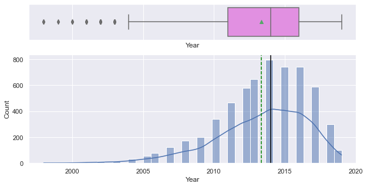

```python
five_number_summary(df2, "Year")
hist_box(df2, "Year")
```

- Most the Manufacturing year of the car falls between 2011 and 2016
- Data has left skewedness, which may require Log Transformation....

  "The log transformation is, arguably, the most popular among the different types of transformations used to transform skewed data to approximately conform to normality. "

### `Analyzing Numeric Columns: Kilometers_Driven`

The total kilometers (a unit used to measure length or distance) driven in the car by the previous owner(s)

```
25% 34000.0
Mean-Green 58738.38029573019
Median-Boxplot 53000.0
75% 73000.0
 StandarD 91268.84320624862
```

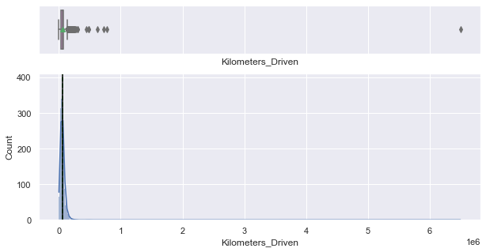

```python
five_number_summary(df2, "Kilometers_Driven")
hist_box(df2, "Kilometers_Driven")
```

### `Analyzing Numeric Columns: Mileage`

The standard mileage offered by the car company in kmpl or km/kg

##### Factors to keep in mind as part of the research

- According to https://www.iea.org/articles/fuel-economy-in-india "Anything that is listed as less than 6-litres/100km or more than 16.5km/1-litre is considered to be pretty good. The first (and most common) reference is litres per 100km (litres/100km). This is how many litres of fuel the car needs in order to travel 100km."

```
25% 15.17
Mean-Green 18.134960943992024
Median-Boxplot 18.15
75% 21.1
 StandarD 4.581527636373601
```

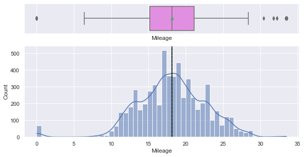

```python
five_number_summary(df2, "Mileage")
hist_box(df2, "Mileage")
```

- Given that "16.5 Kilometers per liter = 16.5 x 2.352146 = 38.81 Miles per gallon." is considered to be pretty good, and in our data we can see that average offered kmpl is at 18.13
- The range of kmpl offered is between 15.17-21.1
- There are outliers in both tail ends, which is making the normal distribution bit imperfect

### `Analyzing Numeric Columns: Engine`

The displacement volume of the engine in CC

Cubic Centimeter

- Engine size is the volume of fuel and air that can be pushed through a car's cylinders and is measured in cubic centimetres (cc)

```
25% 1198.0
Mean-Green 1621.276449941501
Median-Boxplot 1493.0
75% 1969.0
 StandarD 599.553864926071
```

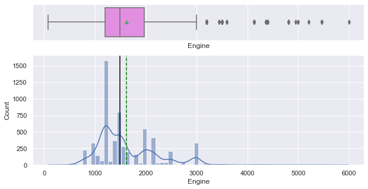

```python
five_number_summary(df2, "Engine")
hist_box(df2, "Engine")
```

- There're few outliers in the Engine Data, as data is skewed right
- Standard deviation is also high
- Engine Sizes varies between 1198 and 1969 with High Standard Deviation
- Given, The fact that the lower the cc of the car, the better the mileage obtained, cars with up to 1000 cc give the best mileage. In our case 25% of the Cars are below 1198 CC.

### `Analyzing Numeric Columns: Power`

The maximum power of the engine in bhp

While hp does not take into account frictional losses in power from an engine, brake horsepower does — meaning hp is always higher than bhp. The difference between the two is small on a 1:1 basis. 1hp is the equivalent to just under 0.99bhp, though scaled up you'll notice differences

The average for crossovers is 200 hp, midsize autos put out 170 hp, while small SUVs are generally capable of 240 hp

```
25% 78.0
Mean-Green 113.25304969366915
Median-Boxplot 98.6
75% 138.03
 StandarD 53.23101941349469
```

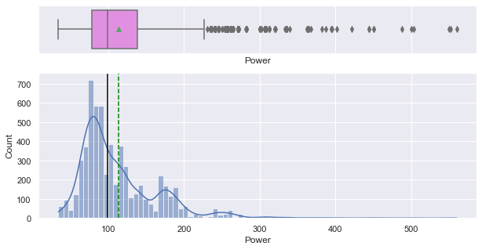

```python
five_number_summary(df2, "Power")
hist_box(df2, "Power")
```

- Given that 250 horsepower in a very small car or about 400 horsepower in an exceptionally large vehicle, 75% of our Power data falls below 138bhp indicating that most of our vehicles are small/sedan type cars
- Given that that an average horse power today is between 180-200 hp, and luxury car's hp starts at 250 on average, from the mean-bhp is at 112bhp in our data most of the vehicles shiuld be light vehicles and non luxury vehicles.

### `Analyzing Numeric Columns: Seats`

The number of seats in the car

```
25% 5.0
Mean-Green 5.278735151413753
Median-Boxplot 5.0
75% 5.0
 StandarD 0.8060121419094122
```

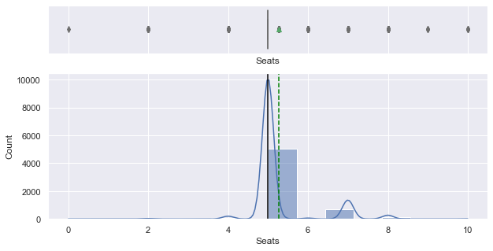

```python
five_number_summary(df2, "Seats")
hist_box(df2, "Seats")
```

- Average seating count for our vehicles is at 5, which is expected and proves that most of the vehicles in our data set are light vehicles (.i.e. Sedans)
- There are some outliers mostly in the right side and data is skewed right as well.
- We can also see that there're very few vehicles that are not 5 seated, as proven by Mean of 5.27

### `Analyzing Numeric Columns: New_Price`

The price of a new car of the same model in INR Lakhs (1 Lakh INR = 100,000 INR)

```
25% 7.88
Mean-Green 21.499854627014454
Median-Boxplot 11.3
75% 21.77
 StandarD 24.332922480840452
```

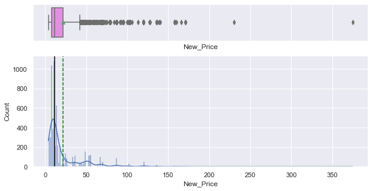

```python
five_number_summary(df2, "New_Price")
hist_box(df2, "New_Price")
```

- Price various between almost 8K and 22K with high Standar deviation
- 75% of the vehicles are under 22K
- There're a lots of outliers on the right side and data is right skewed

### `Analyzing Numeric Columns: Price`

The price of the used car in INR Lakhs

```
25% 3.5
Mean-Green 9.47946835022429
Median-Boxplot 5.64
75% 9.95
 StandarD 11.1879171124555
```

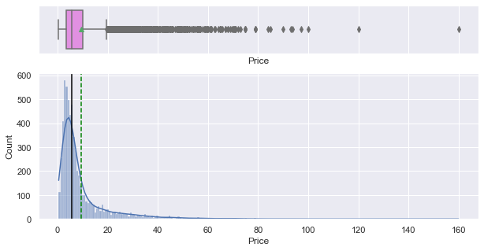

```python
five_number_summary(df2, "Price")
hist_box(df2, "Price")
```

### `Analyzing Categorical Columns: Name`

The price of the used car in INR Lakhs

**Grouping Name columns in below categories since we get an error when plotting**

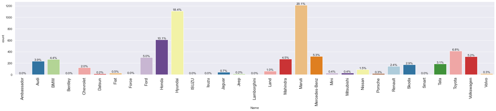

```python
labeled_barplot(df2, "Name", perc=True)
```

- Maruti, Hyundai followed by Honda are the leading car brands
- As below stats shows around 49% of shares in Indian car market are held by below brands
  - Maruti (20%) + Hyundai(18.40%) + Honda(10.10%)= Holds 48.5% of the Indian car market share, meaning that 48.5% of the Indian car market share is held by enocomical fuel efficent vehicles

### `Analyzing Categorical Column: Location`

Location in which the car is being sold or is available for purchase (cities)

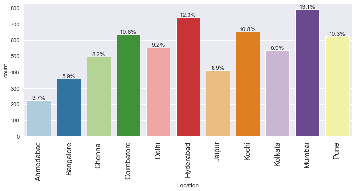

```python
labeled_barplot(df2, "Location", perc=True)
```

### `Analyzing Categorical Column: Fuel_Type`

The type of fuel used by the car (Petrol, Diesel, Electric, CNG, LPG)

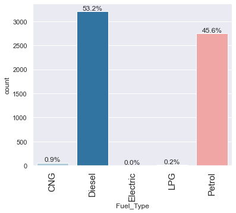

```python
labeled_barplot(df2, "Fuel_Type", perc=True)
```

- Diesel and Petrol fueled vehicles are more common in Indian market than others
- Diesel Vehicles holds more than half of the market share at 53%

### `Analyzing Categorical Column: Transmission`

The type of transmission used by the car (Automatic/Manual)

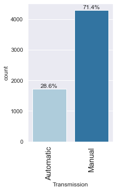

```python
labeled_barplot(df2, "Transmission", perc=True)
```

- Manual Transmission type of cars are preffered over Automatic at 71%, this could be due to better mileage on Manual than Automatic

### `Analyzing Categorical Column: Owner_Type`

Type of ownership

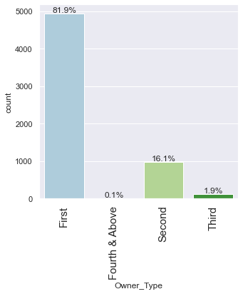

```python
labeled_barplot(df2, "Owner_Type", perc=True)
```

- Large majority of the vehicles are first hand at 82%

### Further Exploring Owner Types for answering below key question

- What is the market share for Pre-owned cars in general?

```python
#  Given below Top selling cars
# Maruti (20%) + Hyundai(18.40%) + Honda(10.10%)= Holds 48.5%
# df2.groupby("Name", as_index=True)[df2["Owner_Type"] == "First"].count().sort_values(
#     ascending=False
# ) / df2.shape[0] * 100

# df2.groupby(["Name"])[df2["Owner_Type"] == "First"].count()
```

## Bivariate Analysis

**Checking Correlation in our Data Set**

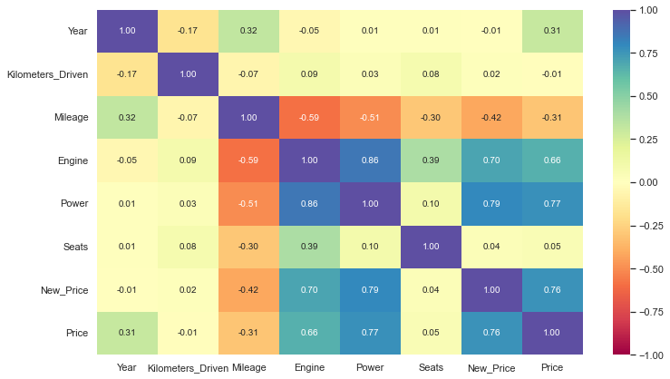

```python
plt.figure(figsize=(12, 7))
sns.heatmap(df2.corr(), annot=True, vmin=-1, vmax=1, fmt=".2f", cmap="Spectral")
plt.show()
```

- `Engine` & `Power` - Highly correlated
- `Power` & `Engine` - Highly correlated
- `New_Price` & `Power` - Highly correlated
- `New_Price` & `Engine` - Highly correlated

Since our objective is simply to predict and not infer, we won't drop the highly correlated independent columns

### `Location` vs `Price`

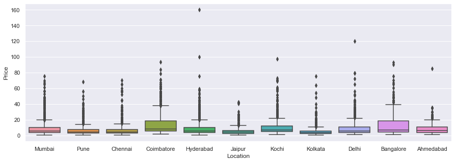

```python
plt.figure(figsize=(15, 5))
sns.boxplot(x="Location", y="Price", data=df2)
plt.show()
```

- Less than 75% of vehicles sold in `Coimbatore & Bangalore` are max $20K
- `Coimbatore, Hyderabad, Kochi, Delhi,Bangalore & Ahmedabad` have Prices over $80K

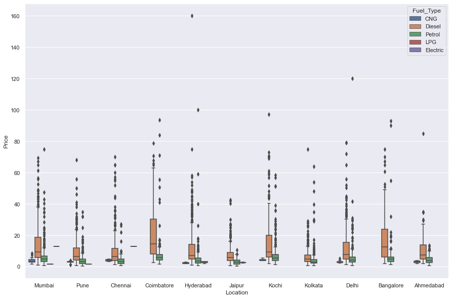

```python
plt.figure(figsize=(15, 10))
sns.boxplot(x="Location", y="Price", hue="Fuel_Type", data=df2)
plt.show()
```

- Vehicles with Fuel_Type Diesel are the top sellers
- Coimbatore has the highest number of Diesel Fuled vehicles sold with Median price over $15K

### `Location&Price` vs `Owner_Type`

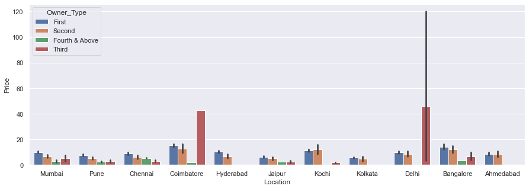

```python
plt.figure(figsize=(15, 5))
sns.barplot(data=df2, x="Location", y="Price", hue="Owner_Type")
```

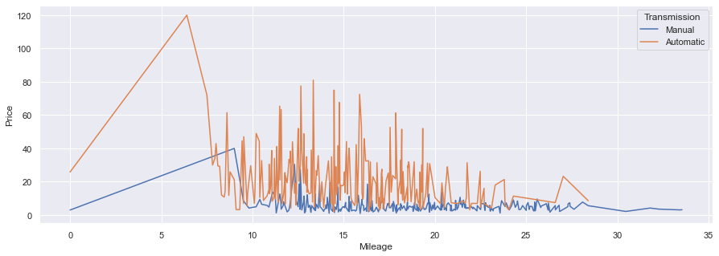

```python
plt.figure(figsize=(15, 5))
sns.lineplot(data=df2, x="Mileage", y="Price", hue="Transmission", ci=None)
plt.show()
```

- Automatic Transmission with offered kpml of around 6.5 are around $120k
- Manual Transmission with offered kpml of around 9.5 are around $40k - this could be Diesel
- Manual Transmission starting with offered kpml of around 10 and above are under $20
- Automatic Transmission starting with offered kpml of around 9 and above are under $80
- Automatic Transmission vehicles are more expensive than Manual in the long run

### Summary of EDA

**Data Description:**

- The target variable (`Price`) is of *float* type.
- Columns like `Name`, `Location`, `Transmission`, `Fuel_Type`,`Owner_Type` are of *object* type.
- All other columns are numeric in nature.
- There are no duplicate values in the data.
- There are a lot of missing values in the data.

**Data Cleaning:**

- The `S.No`dropped as it was just a row ID which Pandas already provided.
- The `Names` column were too long therefore were processed to shorten to Brand names in order to make it into a suitable format for Analysis and Modeling.
- The `Mileage`, `Engine`, `Power` were converted into numeric columns.
- The missing values in the data are treated as follows:
  - Missing values in the target variable `Price` were dropped.
  - Missing values in `Power` were imputed with their mean.
  - Missing values in `Seats` were imputed with their mean.
  - Missing values in `Engine` were imputed with their mean.
  - Missing values in `Mileage` were imputed with their mean.

# **Variable Transformations**

#### Checking the numeric columns for skewness

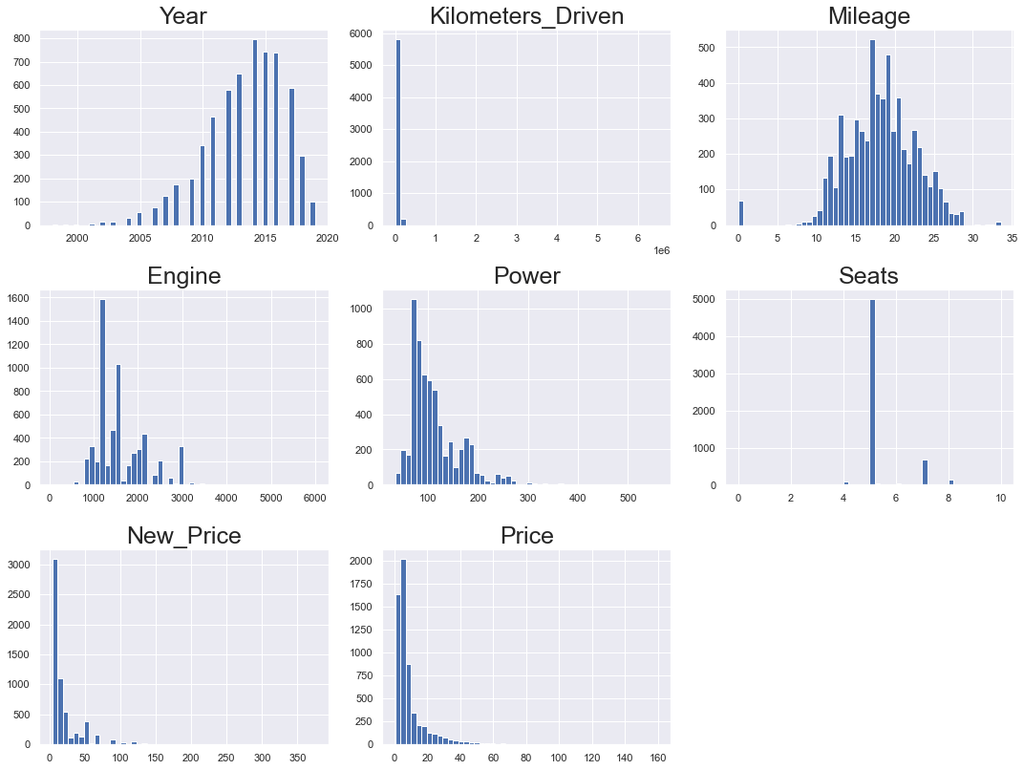

```python
# creating a list of numerical columns
dist_cols = [item for item in df2.select_dtypes(include=np.number)]

# let's plot a histogram of all non-tag columns

plt.figure(figsize=(15, 45))

for i in range(len(dist_cols)):
    plt.subplot(12, 3, i + 1)
    plt.hist(df2[dist_cols[i]], bins=50)
    # sns.histplot(data=df2, x=dist_cols[i], kde=True)  # you can comment the previous line and run this one to get distribution curves
    plt.tight_layout()
    plt.title(dist_cols[i], fontsize=25)

plt.show()
```

**Making the third copy of the Data Set before Log Transoformation**

```python
# Making a copy of df2 to build final model in this ipynb to compare against Base Model
df3 = df2.copy()
```

```python
# using log transforms on some columns

for col in dist_cols:
    df3[col + "_log"] = np.log(df3[col] + 1)

# dropping the original columns
df3.drop(dist_cols, axis=1, inplace=True)
df3.head()
```

|  | Name | Location | Fuel_Type | Transmission | Owner_Type | Year_log | Kilometers_Driven_log | Mileage_log | Engine_log | Power_log | Seats_log | New_Price_log | Price_log |
| --- | --- | --- | --- | --- | --- | --- | --- | --- | --- | --- | --- | --- | --- |
| 0 | Maruti | Mumbai | CNG | Manual | First | 7.606387 | 11.184435 | 3.317816 | 6.906755 | 4.080246 | 1.791759 | 1.873339 | 1.011601 |
| 1 | Hyundai | Pune | Diesel | Manual | First | 7.608871 | 10.621352 | 3.028683 | 7.367077 | 4.845761 | 1.791759 | 2.836737 | 2.602690 |
| 2 | Honda | Chennai | Petrol | Manual | First | 7.606885 | 10.736418 | 2.954910 | 7.090077 | 4.496471 | 1.791759 | 2.262804 | 1.704748 |
| 3 | Maruti | Chennai | Diesel | Manual | First | 7.607381 | 11.373675 | 3.080533 | 7.130099 | 4.497139 | 2.079442 | 2.507157 | 1.945910 |
| 4 | Audi | Coimbatore | Diesel | Automatic | Second | 7.607878 | 10.613271 | 2.785011 | 7.585281 | 4.954418 | 1.791759 | 3.991573 | 2.930660 |

**Checking for skewness after applying the log transformation**

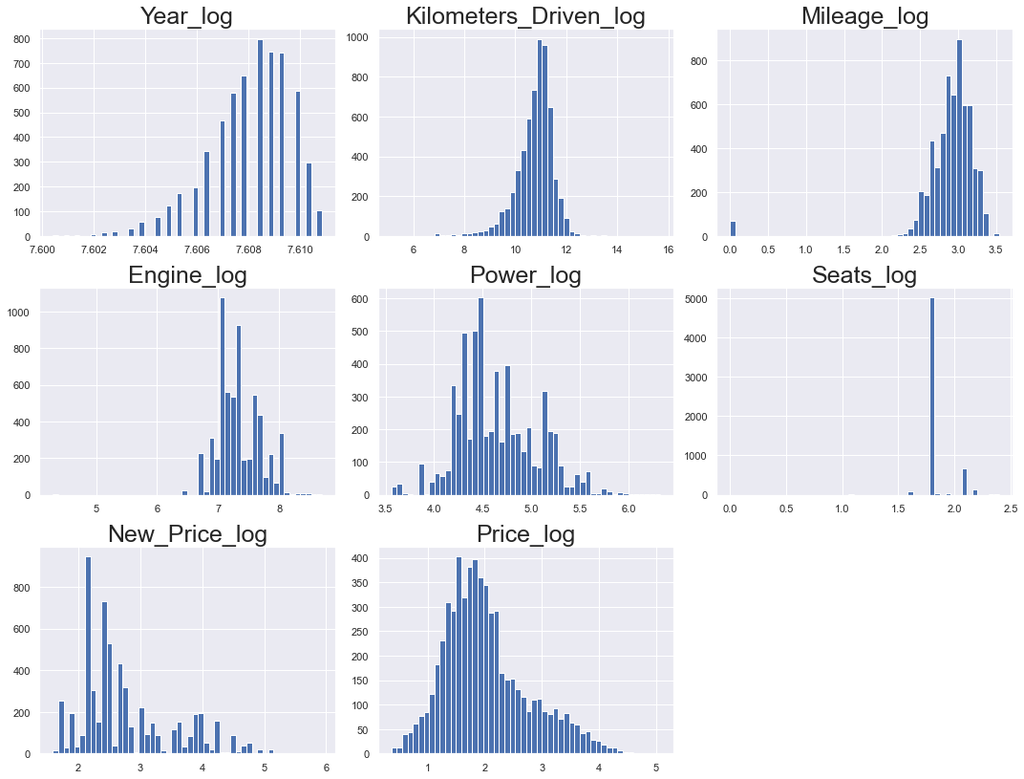

```python
# creating a list of non-tag columns
dist_cols = [item for item in df3.select_dtypes(include=np.number)]

# let's plot histogram of all non-tag columns

plt.figure(figsize=(15, 45))

for i in range(len(dist_cols)):
    plt.subplot(12, 3, i + 1)
    plt.hist(df3[dist_cols[i]], bins=50)
    # sns.histplot(data=df3, x=dist_cols[i], kde=True)  # you can comment the previous line and run this one to get distribution curves
    plt.tight_layout()
    plt.title(dist_cols[i], fontsize=25)

plt.show()
```

- The Columns are still skewed but not as bad as before

**Checking the correlation again after Log transormation**

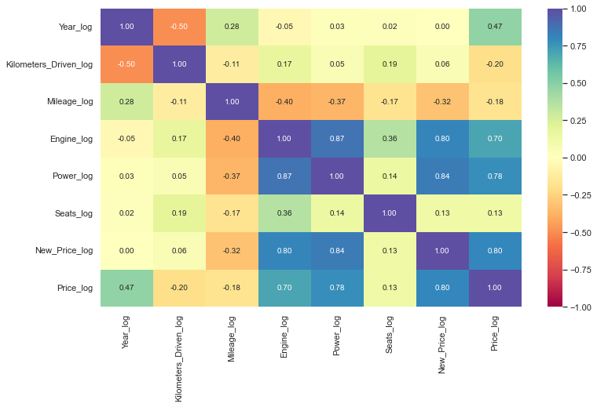

```python
plt.figure(figsize=(12, 7))
sns.heatmap(df3.corr(), annot=True, vmin=-1, vmax=1, fmt=".2f", cmap="Spectral")
plt.show()
```

- There're still few highly correlated columns

# **Model Building**

### Define Dependent Variable

```python
X = df3.drop(["Price_log"], axis=1)
y = df3["Price_log"]
```

### One-Hot Encoding categorical columns before Building ML Models

```python
# See how many objects and categories we have in our third copy of Data Set
X.info()
```

```
<class 'pandas.core.frame.DataFrame'>
RangeIndex: 6019 entries, 0 to 6018
Data columns (total 12 columns):
 #   Column                 Non-Null Count  Dtype
---  ------                 --------------  -----
 0   Name                   6019 non-null   object
 1   Location               6019 non-null   object
 2   Fuel_Type              6019 non-null   object
 3   Transmission           6019 non-null   object
 4   Owner_Type             6019 non-null   object
 5   Year_log               6019 non-null   float64
 6   Kilometers_Driven_log  6019 non-null   float64
 7   Mileage_log            6019 non-null   float64
 8   Engine_log             6019 non-null   float64
 9   Power_log              6019 non-null   float64
 10  Seats_log              6019 non-null   float64
 11  New_Price_log          6019 non-null   float64
dtypes: float64(7), object(5)
memory usage: 564.4+ KB
```

```python
# Converting Objects and Categories into 0's and 1's
X = pd.get_dummies(
    X,
    columns=X.select_dtypes(include=["object", "category"]).columns.tolist(),
    drop_first=True,
)

X.head()
```

|  | Year_log | Kilometers_Driven_log | Mileage_log | Engine_log | Power_log | Seats_log | New_Price_log | Name_Audi | Name_BMW | Name_Bentley | Name_Chevrolet | Name_Datsun | Name_Fiat | Name_Force | Name_Ford | Name_Honda | Name_Hyundai | Name_ISUZU | Name_Isuzu | Name_Jaguar | Name_Jeep | Name_Lamborghini | Name_Land | Name_Mahindra | Name_Maruti | Name_Mercedes-Benz | Name_Mini | Name_Mitsubishi | Name_Nissan | … |
| --- | --- | --- | --- | --- | --- | --- | --- | --- | --- | --- | --- | --- | --- | --- | --- | --- | --- | --- | --- | --- | --- | --- | --- | --- | --- | --- | --- | --- | --- | --- |
| 0 | 7.606387 | 11.184435 | 3.317816 | 6.906755 | 4.080246 | 1.791759 | 1.873339 | 0 | 0 | 0 | 0 | 0 | 0 | 0 | 0 | 0 | 0 | 0 | 0 | 0 | 0 | 0 | 0 | 0 | 1 | 0 | 0 | 0 | 0 | … |
| 1 | 7.608871 | 10.621352 | 3.028683 | 7.367077 | 4.845761 | 1.791759 | 2.836737 | 0 | 0 | 0 | 0 | 0 | 0 | 0 | 0 | 0 | 1 | 0 | 0 | 0 | 0 | 0 | 0 | 0 | 0 | 0 | 0 | 0 | 0 | … |
| 2 | 7.606885 | 10.736418 | 2.954910 | 7.090077 | 4.496471 | 1.791759 | 2.262804 | 0 | 0 | 0 | 0 | 0 | 0 | 0 | 0 | 1 | 0 | 0 | 0 | 0 | 0 | 0 | 0 | 0 | 0 | 0 | 0 | 0 | 0 | … |
| 3 | 7.607381 | 11.373675 | 3.080533 | 7.130099 | 4.497139 | 2.079442 | 2.507157 | 0 | 0 | 0 | 0 | 0 | 0 | 0 | 0 | 0 | 0 | 0 | 0 | 0 | 0 | 0 | 0 | 0 | 1 | 0 | 0 | 0 | 0 | … |
| 4 | 7.607878 | 10.613271 | 2.785011 | 7.585281 | 4.954418 | 1.791759 | 3.991573 | 1 | 0 | 0 | 0 | 0 | 0 | 0 | 0 | 0 | 0 | 0 | 0 | 0 | 0 | 0 | 0 | 0 | 0 | 0 | 0 | 0 | 0 | … |

### Split the data into train and test

```python
x_train, x_test, y_train, y_test = train_test_split(X, y, test_size=0.3, random_state=1)
```

```python
print("Number of rows in train data =", x_train.shape[0])
print("Number of rows in test data =", x_test.shape[0])
```

```
Number of rows in train data = 4213
Number of rows in test data = 1806
```

### Fitting a linear model

```python
lin_reg_model = LinearRegression()
lin_reg_model.fit(x_train, y_train)
```

```
LinearRegression()
```

### Model performance check

- We will be using metric functions defined in sklearn for RMSE, MAE, and $R^2$.
- We will define functions to calculate adjusted $R^2$ and MAPE.
  - The mean absolute percentage error (MAPE) measures the accuracy of predictions as a percentage, and can be calculated as the average absolute percent error for each predicted value minus actual values divided by actual values. It works best if there are no extreme values in the data and none of the actual values are 0.
- We will create a function that will print out all the above metrics in one go.

```python
# Checking model performance on train set
print("Training Performance\n")
lin_reg_model_train_perf = model_performance_regression(lin_reg_model, x_train, y_train)
lin_reg_model_train_perf
```

```
Training Performance
```

|  | RMSE | MAE | R-squared | Adj. R-squared | MAPE |
| --- | --- | --- | --- | --- | --- |
| 0 | 0.188835 | 0.135803 | 0.935939 | 0.935092 | 7.88378 |

```python
# Checking model performance on test set
print("Test Performance\n")
lin_reg_model_test_perf = model_performance_regression(lin_reg_model, x_test, y_test)
lin_reg_model_test_perf
```

```
Test Performance
```

|  | RMSE | MAE | R-squared | Adj. R-squared | MAPE |
| --- | --- | --- | --- | --- | --- |
| 0 | 0.174801 | 0.129295 | 0.946049 | 0.944354 | 7.423128 |

**Observations**

- The train and test $R^2$ are 0.93 and 0.94, indicating that the model explains 93% and 94% of the total variation in the train and test sets respectively. Also, both scores are comparable.
- RMSE values on the train and test sets are also comparable, RMSE value in training 0.18 and test 0.17

which indicates to a better fit since RMSE has dropped in Test Data.

- This shows that the model is not overfitting.
- MAE indicates that our current model is able to predict price of used cars within a mean error of 0.12 on the test set.
- MAPE of 7.42 on the test data means that we are able to predict ~8% of the price of used cars,

this also means that forecasted value and the actual value is 7.42% which was at 7.88 in Training Set.

- The overall performance is much better than the model we built in the previous session.

### Conclusions & Recommendation that will help business

- We have been able to build a predictive model that can be used by the business to predict the price of used cars with an $R^2$ of 0.935 on the training set and 0.946 on the Test data set
- Business can use this model to predict the price of used cars within a mean error of 0.12 on the test set.
- We improved our linear regression model performance by applying non-linear transformations to some of the attributes.
  - RMSE in base model is at 5.31 for Training and 6.17 for Test, where as after Variable Transformation it has gone down to 0.18 in Train and 0.17 in Test.
  - Mean Absolute Error has also gone down to 0.13 Train/ 0.12 Test in our current latest model from 2.86 Train / 2.78 from Base Model
  - Final model's $R^2$ has increased by 27% in Test model to being 94%, meaning that it explain 27% more of the Total Variation, where in base model it was just at 67%
  - Adjusted $R^2$ score in Test and Train has also gone up to little over 20% as well.

#### Given below market conditions:

- Maruti, Hyundai and Honda accounts for 49% of the Indian Car Market's share, Meaning market is Dominated mainly by economical cars which are mainly of Diesel Fuel_Type.
- The Median price of New car is at 11.3K where as pre-owned cars are at 6k and Manual Transmission is most preferred amongst drivers
- Second Owner_Type vehicles accounts for 16.15% of the market share where as First hand type of cars accounts for 82%.
- Delhi and Comibatore Sales on Thirda hand vehicles can top to 40K median price point

#### This could mean that:

- There's a gap in the market due to the limit of inventory on used cars, which might explain the increase value for third hand cars in Delhi and Coimbatore at 40K while first, second hand cars are just under 20K

#### Business can look into:

1. Closing this gap by building a smart and diverse inventory which consists of economical cars that are fueled by petrol, diesle and electricity
2. While proviiding future potential buyers more options to choose from, the cars4u can make this options easier to choose from by running smart ad campaigns on each vehicles advnatage on mileage, comfort, reliability etc...
3. Delhi and Coimbatore should be our focus markets
4. Using our model Cars4U can better predict based on current data, and even much more going forward as more sales will lead to more data to be analyzed and predit price for pre-owned vehicles.